# Strauss shipwrecks network

Antonio Rivero Ostoic

CEDHAR, Aarhus University

jaro@cas.au.dk

11 januar 2022

This post concerns the Strauss Shipwrecks database:

Strauss, J. (2013). Shipwrecks Database. Version 1.0. Accessed (07-12-2021) from oxrep.classics.ox.ac.uk/databases/shipwrecks_database/

## Requirements

To run the code snippets below, we need the following `R` packages

```r
# v0.7.4 or higher
library("sdam")
library("readxl")
# v2.9.7 or higher
library("multiplex")
library("multigraph")
```

## Shipwrecks database

Andrew Wilson coordinates a catalogue of all known ancient wrecks in the Mediterranean up to 1500 AD where there is the database from Julia Strauss’s PhD thesis *Roman Cargoes: Underwater Evidence from the East* (London 2007).

### Retrieving the data

The Shipwrecks Database is distributed as a `ZIP` *filesystem* that needs a temporal file where to download it. The workflow below gives the steps in `R` with credits to [this discussion](https://stackoverflow.com/questions/3053833/).

```r
temp <- tempfile()
download.file("http://oxrep.classics.ox.ac.uk/docs/StraussShipwrecks.zip", temp)
```

Next, we make the connection with the temporal file and unzip it with the `"utils"` package into object `con`, and because `StraussShipwrecks` is an MS Excel file with different sheets, we use package `"readxl"` to recursively read the excel sheets.

```r
# connect temporal file and unzip excel file
con <- utils::unzip(temp, "StraussShipwrecks.xlsx")
```

```r
# recursively read Excel sheets
allsheets <- sapply(readxl::excel_sheets(con), simplify=FALSE, USE.NAMES=TRUE,
            function(z) readxl::read_excel(con, sheet = z))
```

Before continuing with the analysis, however, we need to close the connections and remove unused files.

```r
# close connection and garbage collection
CatchupPause <- function(Secs){
 Sys.sleep(Secs) # pause to let connection work
 closeAllConnections()
 gc()
}

# close also with temporal file
unlink(temp)
```

### Analysis

We look at this database with the `"base"` `summary()` function.

```r
# content in the excel sheets
summary(allsheets)
```

```
           Length Class  Mode
Shipwrecks 35     tbl_df list
Amphorae    5     tbl_df list
```

Where we can see that actually the database contains two datasets, `Shipwrecks` and `Amphorae`, which are components having 35 and 5 variables, respectively. We also notice that package `"readxl"` stores these data frames with a *tibble* flavour.

The first component of the database has the shipwrecks dataset recorded in `sw` where the variables are listed in the column names.

```r
# shipwrecks dataset
sw <- allsheets$Shipwrecks
# class object
class(sw)
```

```
[1] "tbl_df"     "tbl"        "data.frame"
```

```r
# variables in dataset
colnames(sw)
```

```
 [1] "Wreck ID"                "Strauss ID"              "Name"
 [4] "Parker Number"           "Sea area"                "Country"
 [7] "Region"                  "Latitude"                "Longitude"
[10] "Min depth"               "Max depth"               "Depth"
[13] "Period"                  "Dating"                  "Earliest date"
[16] "Latest date"             "Date range"              "Mid point of date range"
[19] "Probability"             "Place of origin"         "Place of destination"
[22] "Reference"               "Comments"                "Amphorae"
[25] "Marble"                  "Columns etc"             "Sarcophagi"
[28] "Blocks"                  "Marble type"             "Other cargo"
[31] "Hull remains"            "Shipboard paraphernalia" "Ship equipment"
[34] "Estimated tonnage"       "Amphora type"
```

#### Timespans of existence

Use function `plot.dates()` from package `"sdam"` to plot the timespans of existence of the shipwrecks that are in variables `'Earliest date'` and `'Latest date'`.

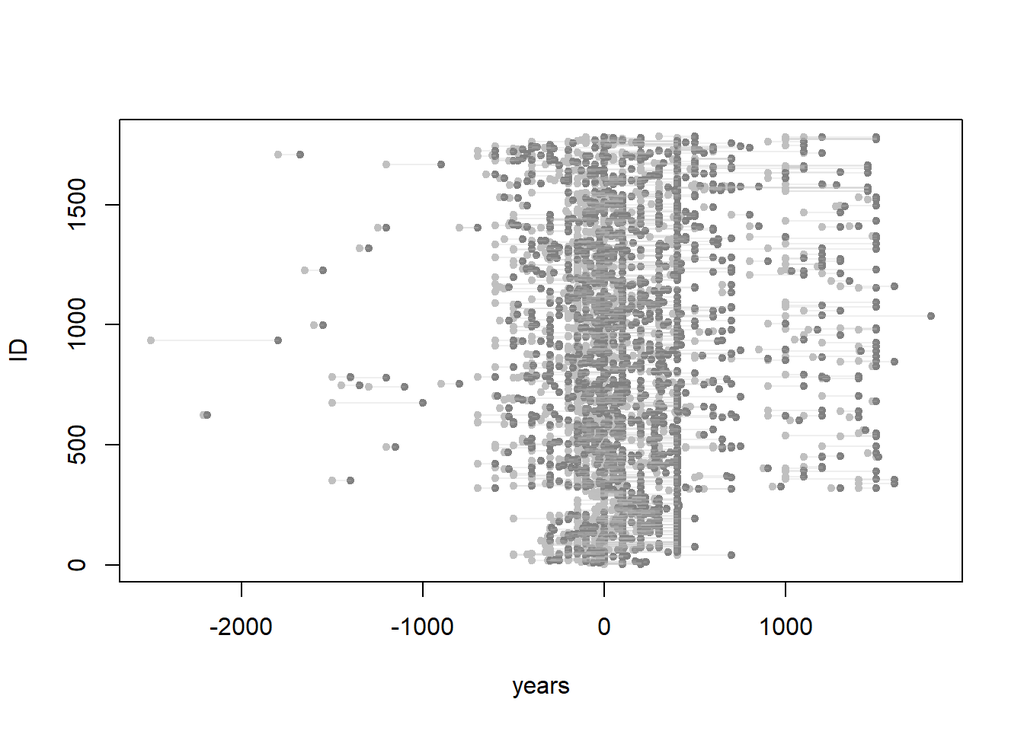

Shipwrecks timespans of existence

```r
# plot shipwrecks timespans
sdam::plot.dates(sw, taq="Earliest date", tpq="Latest date")
```

Alternatively, plot with `plot.dates()` using the two IDs existing in the dataset, which are `Wreck ID` and `Strauss ID`.

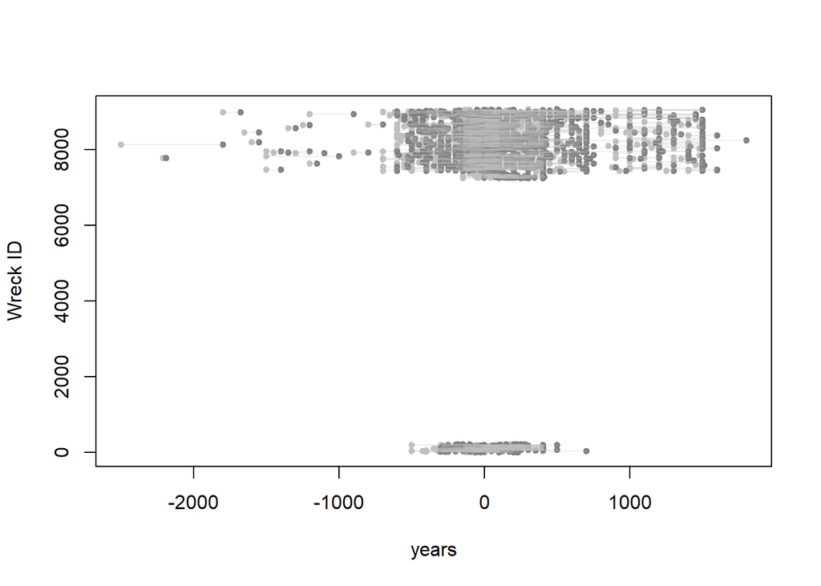

```r
# use Wreck ID
plot.dates(sw, id="Wreck ID",
           taq="Earliest date", tpq="Latest date")
```

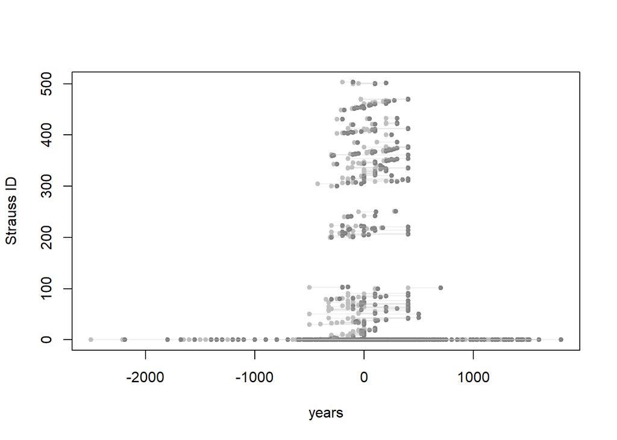

```r
# use Strauss ID
plot.dates(sw, id="Strauss ID",
           taq="Earliest date", tpq="Latest date")
```

### Network relations

The shipwrecks dataset has relational information as well that can have a network representation. We extract from `allsheets` the data frame component with Strauss shipwrecks dataset into object `ss`, where the network data is in variables `Place of origin` and `Place of destination` that are columns 20 and 21 in this new object.

```r
# Strauss shipwrecks dataset
ss <- as.data.frame(sw)
```

```r
# look at the first records
head(ss[,20:21])
```

```
  Place of origin Place of destination
1           Egypt       Northern Italy
2             Cos       Northern Italy
3          Rhodes       Northern Italy
4          Aegean       Northern Italy
5            <NA>                 <NA>
6          Rhodes       northern Italy
```

We can see, however, that some record entries need cleaning from question marks, spaces, etc. and which can be seen in the two variables in columns `20` and `21`.

```r
# place of origin
require("magrittr")
ss[ ,20] %>%
  unique() %>%
  sort() %>%
  head()
```

```
[1] "?"                                  "Adriatic"
[3] "Adriatic - Brindisi - Campania"     "Adriatic via Africa, Spain, France"
[5] "Adriatic?"                          "Aegean"
```

```r
# place of destination
require("magrittr")
ss[ ,21] %>%
  unique() %>%
  sort() %>%
  head()
```

```
[1] "?"                       "a palace in the Aegean?" "Adriatic/ further east?"
[4] "Aegean"                  "Aegean?"                 "Aegean? Rome?"
```

#### Edge list

First, we create the edge list object `edgel` with the two network variables in `ss` and a column `'tie'` for indicating the ties.

```r
# bind three columns where the last one is for the ties
edgel <- cbind(ss[ ,20:21], tie=rep(1, nrow(ss)))
```

The excerpt below is an example of how one can *clean* records `9`, `35`, `130` in data as given in `edgel`.

```r
# three records in edgelist
edgel[c(9,35,130), ]
```

```
     Place of origin          Place of destination tie
9            Aegean.                          Rome   1
35              Cos?                    Black Sea?   1
130 Tripolitania (?) Brega, for trans shipment (?)   1
```

The `"sdam"` internal function `cln()` removes special characters that can be made explicit as well.

```r
# default clean
sdam::cln(edgel[c(9,35,130), ])
```

```
    Place.of.origin         Place.of.destination tie
9           Aegean.                         Rome   1
35              Cos                    Black Sea   1
130 Tripolitania () Brega, for trans shipment ()   1
```

```r
# include parenthesis in clean
cln(edgel[c(9,35,130), ], what=c("(",")"))
```

```
    Place.of.origin       Place.of.destination tie
9           Aegean.                       Rome   1
35              Cos                  Black Sea   1
130   Tripolitania  Brega, for trans shipment    1
```

```r
# also remove in clean dots and spaces at the end
cln(edgel[c(9,35,130), ], level=2, what=c("(",")"))
```

```
    Place.of.origin      Place.of.destination tie
9            Aegean                      Rome   1
35              Cos                 Black Sea   1
130    Tripolitania Brega, for trans shipment   1
```

The first option removes only characters `?*+`, and the second one removes also parenthesis. The command with a raised `"level"` removes also unnecessary spaces and dots at the end of each record. Cleaning the data set is needed before constructing the set of relations for the Strauss shipwrecks network.

#### Network graph and components

The code below uses function `read.srt()` from package `"multiplex"` to transform the edge list into the *adjacency matrix* of the network in object `mat`.

```r
# construct matrix from cleaned edge list
mat <- multiplex::read.srt(sdam::cln(edgel, level=2, what=c("(",")")))
```

Then we plot with package `"multigraph"` the Strauss shipwrecks network as a directed graph using a layout algorithm.

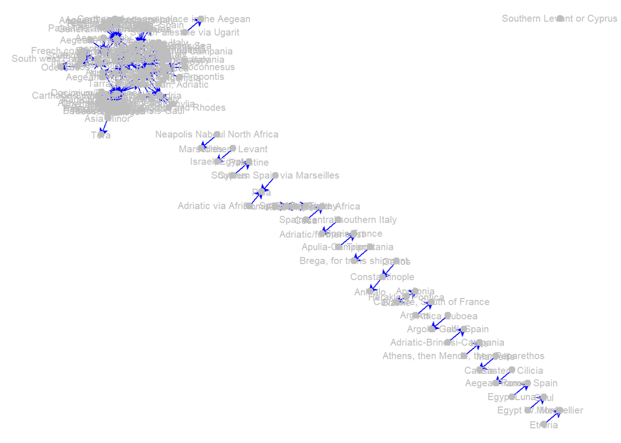

Graph for Strauss shipwrecks network.

```r
# plot customized graph
multigraph::multigraph(mat, layout="force", seed=23, pos=0, ecol="blue", col=8, fcol=8)
```

With the force-directed layout of the graph above, it is easy to see network components. Ideally, the last place of destination in the above example, which is `Brega, for trans shipment` should be more specific perhaps. There may be other records like that one and some of the dyadic components are indeed part of the largest component of the Strauss shipwrecks network; however, the rest of the adjustments needs to be by hand by or in coordination with a domain expert.

Function `comps()` from package `"multiplex"` provides the network components and isolates with the relations recorded in the adjacency matrix.

```r
# network components
multiplex::comps(mat)
```

```
$com
$com[[1]]
[1] "a palace in the Aegean"     "Syria/Palestine via Ugarit"

$com[[2]]
 [1] "Aegean Tripolitania Italy"       "NA"
 [3] "Narbonne, France"                "North Africa"
 [5] "northern Italy"                  "Northern Italy"
 [7] "Odessos"                         "Palestine and elsewhere"
 [9] "Aegean via Cosa"                 "Palestine Cilicia, Aegean"
[11] "Palestine/Rhodes"                "Pamphylia"
[13] "Paros"                           "Pergamum"
[15] "Phoenicia"                       "Rhodes"
[17] "Rhodes, Cos"                     "Aegean via southern Italy"
[19] "Rome"                            "Samos"
[21] "Sicily"                          "Sicily/Rome"
[23] "South coast Black Sea"           "South of France"
[25] "South west France Inland France" "Southern Italy"
[27] "Aegean, Italy"                   "Spain"
[29] "Spain, Aegean, Adriatic"         "Tarraconensis"
[31] "Teos, Naxos, Rome"               "Tera"
[33] "Aegean/Africa"                   "Thasos"
[35] "Thasos/Asia Minor"               "Thessaly, Proconnesus"
[37] "Thessaly/Euboea"                 "Aegean/N. Africa/Propontis"
[39] "Africa"                          "Alex/Pergamum/Aegean"
[41] "Alexandria"                      "Adriatic"
[43] "Aquileia"                        "Asia Minor"
[45] "Assos"                           "Athens"
[47] "Athens via Delos"                "Baetica"
[49] "Baetica-Tarraconensis-Gaul"      "Black Sea"
[51] "Cadiz"                           "Caesarea"
[53] "Caesarea Maritima"               "Cartagena, Spain"
[55] "Carthage"                        "Carthage-Spain-Sicily/Sardinia"
[57] "Carthage Aegean"                 "Carystos"
[59] "central western Italy"           "Chemtou, Tunisia"
[61] "Chios"                           "Cnidus"
[63] "Corinth"                         "Cos"
[65] "Cos, Crete, Italy"               "Cos, Rhodes"
[67] "Cos, Rhodes, Athens"             "Crete"
[69] "Aegean"                          "Cyprus/Levant"
```

[output cut: 63 more lines]

```
$com[[19]]
[1] "Eastern Cilicia" "Aegean Rome"

$com[[20]]
[1] "Egypt Luna"    "France, Spain"

$com[[21]]
[1] "Egypt W. Med" "Gaul"

$com[[22]]
[1] "Etruria"     "Montpellier"


$isol
[1] "Southern Levant or Cyprus"
```

By selecting the largest component with function `rel.sys()`, we obtain the adjacency matrix as an array object in `matc`.

```r
# adjacency matrix of the largest component
matc <- multiplex::rel.sys(mat, type="toarray", sel=multiplex::comps(mat)$com[[2]])

# matrix size
dim(matc)
```

```
[1] 96 96
```

Then plot the largest component in the shipwrecks network where locations and their connections are easier to see.

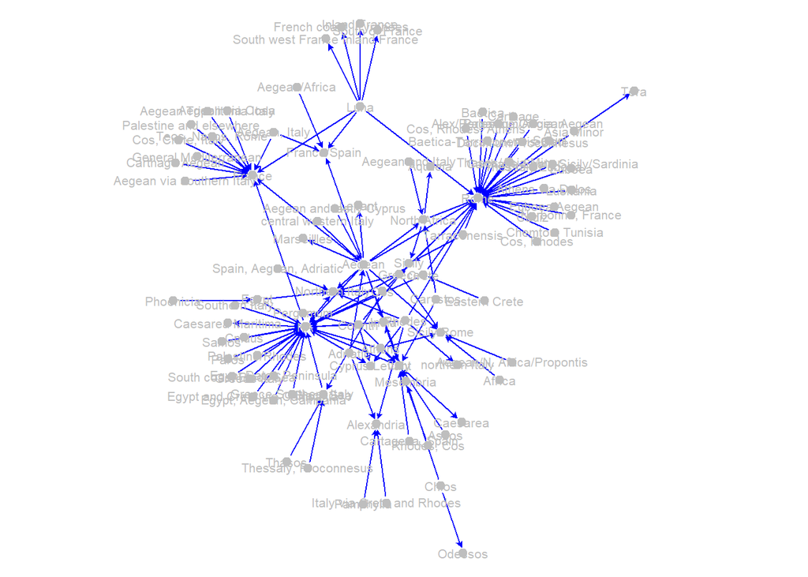

Graph for largest component in Strauss shipwrecks network.

```r
# graph of largest component with adjusted vertex-edge distance
multigraph(matc, layout="force", seed=23, pos=0, ecol="blue", col=8, fcol=8)
```

¨

### See also

- [Centrality measures in ORBIS Roman transport network](https://htmlpreview.github.io/?https://github.com/sdam-au/R_code/blob/master/HTML/Centrality%20measures%20in%20ORBIS%20Roman%20transport%20network.html)
- [ORBIS Roman World transport network](https://htmlpreview.github.io/?https://github.com/sdam-au/R_code/blob/master/HTML/ORBIS%20Roman%20World%20transport%20network%20centrality%20measures.html)
- [Plotting Roman Empire transport network](https://sdam-au.github.io/sdam/articles/TransportNetwork.html)
- [Plotting ancient Roman provinces and regions](https://sdam-au.github.io/sdam/articles/RomanProvs.html)
- [Re-encoding Greek characters from ‘EDH’ dataset](https://sdam-au.github.io/sdam/articles/Encoding.html)
- [`"sdam"` manual](https://github.com/mplex/cedhar/blob/master/typesetting/reports/sdam.pdf)
- [Social Dynamics and complexity in the Ancient Mediterranean Project](https://sdam-au.github.io/sdam-au/)